# Analisis Regresi Kelompok 16

Haidar Ramdhani

2024-02-11

## Read Data

Data yang digunakan adalah data Tingkat Bunuh Diri dan Harapan Hidup yang diperoleh dari link berikut https://www.kaggle.com/datasets/marshuu/suicide-rate-and-life-expectancy

```r
data.a <- read.csv("D:\\Campss\\Season 4\\Anreg\\P3\\archive (9)\\Life expectancy.csv")
data.b <- read.csv("D:\\Campss\\Season 4\\Anreg\\P3\\archive (9)\\Suicide Rate.csv")

data <- merge(data.a, data.b, by = "Country")

datset <- data[,c(1,4,7)]
y <- datset$Suicide.rate
x <- datset$Happiness.Score
n <- nrow(datset)
```

#### Statistik lima serangkai peubah x dan y

```r
summary(x)
```

```
##    Min. 1st Qu.  Median    Mean 3rd Qu.    Max.
##   3.351   4.731   5.642   5.580   6.441   7.769
```

```r
summary(y)
```

```
##    Min. 1st Qu.  Median    Mean 3rd Qu.    Max.
##    9.60   12.50   14.35   15.85   17.60   39.70
```

## Persamaan Regresi Linear Sederhana

```r
model <- lm(formula=y~x, data = datset)
summary(model)
```

```
##
## Call:
## lm(formula = y ~ x, data = datset)
##
## Residuals:
##    Min     1Q Median     3Q    Max
## -6.225 -3.339 -1.478  1.741 23.895
##
## Coefficients:
##             Estimate Std. Error t value Pr(>|t|)
## (Intercept) 15.52831    2.51163   6.183 7.57e-09 ***
## x            0.05711    0.44198   0.129    0.897
## ---
## Signif. codes:  0 '***' 0.001 '**' 0.01 '*' 0.05 '.' 0.1 ' ' 1
##
## Residual standard error: 5.471 on 130 degrees of freedom
## Multiple R-squared:  0.0001284,  Adjusted R-squared:  -0.007563
## F-statistic: 0.0167 on 1 and 130 DF,  p-value: 0.8974
```

```r
b0 <- model$coefficients[[1]]
b1 <- model$coefficients[[2]]

b0;b1
```

```
## [1] 15.52831
```

```
## [1] 0.05711204
```

Berdasarkan perhitungan dari fungsi tersebut, diperoleh dugaan persamaan regresi linear atau nilai harapan dari peubah respons Y sebagai berikut.
$$\hat{E[Y]} = \hat{Y} = \beta_1X + \beta_0 \\
\hat{E[Y]} = \hat{Y} = 0.05711204X + 15.52831$$
**Interpretasi Persamaan:**

1. Jika angka kebahagiaan di suatu negara bernilai 0, maka rata-rata masih terdapat kasus bunuh diri dengan angka 15.52831 yang dapat terjadi karena faktor lain 2. Jika angka kebahagiaan di suatu negara meningkat 1 satuan, maka rata-rata angka kasus bunuh diri akan meningkat sebesar 0.05711204

## Scatter Plot

Melalui scatter plot untuk regresi linear sederhana ini, akan diduga angka bunuh diri terhadap angka kebahagiaan di dunia, sehingga angka bunuh diri dideklarasikan sebagai y dan angka kebahagiaan sebagai x.

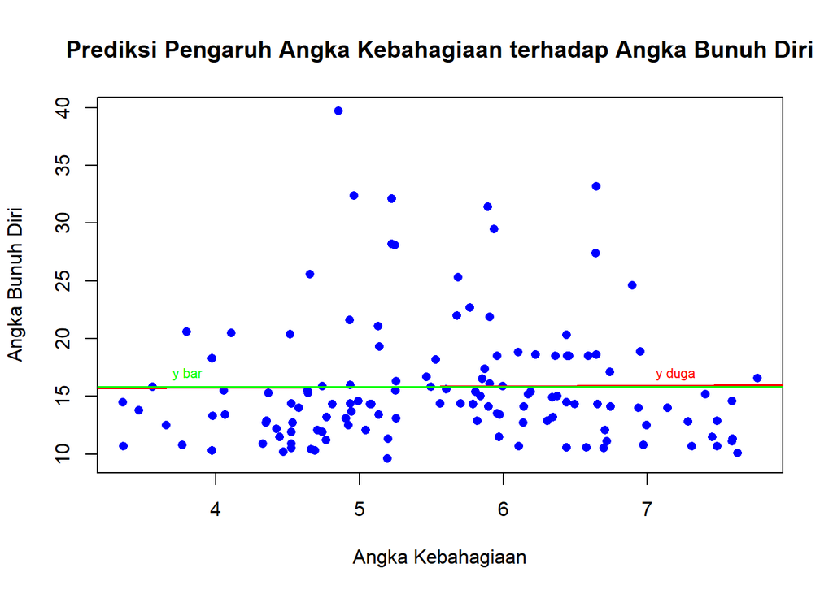

```r
ybar <- mean(y)

{plot(x,y, pch = 16, col = "blue",
      xlab = "Angka Kebahagiaan",
      ylab = "Angka Bunuh Diri",
      main = "Prediksi Pengaruh Angka Kebahagiaan terhadap Angka Bunuh Diri")
abline(model, col="red", lwd = 1.5)
abline(h=ybar, col="green", lwd = 1.5)
text(x = 3.8, y = 17, "y bar", col = "green", cex = 0.7)
text(x = 7.2, y = 17, "y duga", col = "red", cex = 0.7)
}
```

Pada plot tersebut, garis merah adalah garis persamaan regresi sementara garis hijau adalah garis dari rataan nilai y (angka bunuh diri). Terlihat bahwa titik-titik koordinat tersebar, jauh dari garis regresi. Hal ini menandakan bahwa galatnya besar.

## ANOVA

```r
anova_model <- anova(model)
anova_model
```

```
## Analysis of Variance Table
##
## Response: y
##            Df Sum Sq Mean Sq F value Pr(>F)
## x           1    0.5  0.4998  0.0167 0.8974
## Residuals 130 3891.4 29.9336
```

#### Inisialisasi nilai y dugaan

```r
y_duga <- 0
for (i in 1:length(y)){
  y_duga[i] <-  b1*x[i] + b0
}
y_duga
```

```
##   [1] 15.74499 15.81153 15.84842 15.92552 15.76275 15.87681 15.89183 15.80547
##   [9] 15.94597 15.95414 15.82124 15.90473 15.89942 15.78685 15.88177 15.86481
##  [17] 15.95145 15.86561 15.80947 15.81815 15.82181 15.82792 15.78628 15.88389
##  [25] 15.85310 15.81067 15.73146 15.79325 15.78200 15.96419 15.71969 15.75978
##  [33] 15.91347 15.86561 15.85984 15.77760 15.72603 15.80085 15.91136 15.79468
##  [41] 15.86367 15.89245 15.91376 15.90787 15.96213 15.78680 15.88097 15.86938
##  [49] 15.86858 15.81621 15.85887 15.81016 15.80850 15.92232 15.78960 15.84425
##  [57] 15.97201 15.90850 15.81335 15.78080 15.82672 15.92781 15.79599 15.89702
##  [65] 15.86264 15.85402 15.76041 15.73688 15.79411 15.74339 15.86076 15.86858
##  [73] 15.96202 15.78685 15.82158 15.79713 15.79896 15.92678 15.95596 15.89622
##  [81] 15.86510 15.89634 15.81849 15.85762 15.78366 15.81010 15.87709 15.80307
##  [89] 15.90787 15.84048 15.75510 15.75556 15.89051 15.90770 15.93626 15.78674
##  [97] 15.75521 15.87903 15.82803 15.77697 15.89617 15.82832 15.78714 15.86950
## [105] 15.90399 15.84225 15.86732 15.82672 15.85265 15.82832 15.77532 15.80062
## [113] 15.80993 15.79348 15.95596 15.94443 15.84597 15.77663 15.72003 15.96202
## [121] 15.88846 15.82495 15.87069 15.91102 15.79896 15.86190 15.87892 15.82523
## [129] 15.89622 15.89074 15.91210 15.92467
```

$$JKR = \sum_{i=1}^{n}(\hat{y}_i - \bar{y})^2 \\
JKT = \sum_{i=1}^{n}(y_i - \bar{y})^2 \\
JKG = \sum_{i=1}^{n}(y_i - \hat{y}_i)^2$$

```r
JKR <- 0
JKT <- 0
JKG <- 0

for (i in 1:length(y)){
  JKR <-  JKR + (y_duga[i] - ybar)^2
  JKT <-  JKT + (y[i] - ybar)^2
  JKG <- JKG + (y[i] - y_duga[i])^2
}
JK_num <- c(JKR, JKT, JKG)
JK <- c("JKR", "JKT", "JKG")
data.frame(JK, JK_num)
```

```
##    JK       JK_num
## 1 JKR    0.4998123
## 2 JKT 3891.8687879
## 3 JKG 3891.3689755
```

Melalui perhitungan tersebut, diperoleh nilai JKR, JKT, dan JKG dengan nilai di atas.

#### Koefisien Determinasi

$$R^2 = \frac{JKR}{JKT}$$

```r
Rsq <- JKR/JKT
Rsq
```

```
## [1] 0.0001284248
```

Koefisien determinasinya adalah 0,0001284248 atau sekitar 0.012%. Angka ini sangat kecil, mengindikasikan bahwa terdapat hubungan yang sangat kecil antara angka kebahagiaan dengan angka bunuh diri di dunia.

#### Pendugaan Parameter b0 dan b1 $$KTR = \frac{JKT}{1}; \ \ KTG = \frac{JKG}{n-2}\\ S_{xx} = \sum_{i=1}^{n}(x_i - \bar x)^2\\ S_e^2 =KTG; \ \ S^2_{\beta_1} = \frac{S_e^2}{S_{xx}}; \ \ S^2_{\beta_0} = \frac{S^2_e\sum_{i=1}^{n}x_i^2}{n\sum(x_i - \bar x)^2}$$

```r
KTR <- JKT
KTG <- JKG/(n-2)
Se_sq <- KTG

xbar <- mean(x)

Sxx <- 0
sum_x_sq <-0
for (i in 1:length(x)){
  Sxx <- Sxx + (x[i] - xbar)^2
  sum_x_sq <- sum_x_sq + (x[i])^2
}


Sb1_sq <- Se_sq/Sxx
Sb0_sq <- (Se_sq*sum_x_sq)/(n*Sxx)

Sb1_sq;Sb0_sq
```

```
## [1] 0.1953473
```

```
## [1] 6.308289
```

$$Uji \ Hipotesis \ \beta_1 \\
H_0 : \beta_1 = 0 \\
H_1 : \beta_1 \neq 0\\$$

$$t = \frac{b_1 - \beta_1}{S_{b_1}}$$

```r
alpha <- 0.05
thit_b1 <- (b1 - 0)/sqrt(Sb1_sq)
ttab_b1 <- abs(qt(alpha/2,n-2))

thit_b1;ttab_b1
```

```
## [1] 0.1292183
```

```
## [1] 1.97838
```

t hitung < |t tabel|, maka terima H0. Tidak terdapat cukup bukti untuk menyatakan bahwa b1 tidak sama dengan 0.

$$Uji \ Hipotesis \ \beta_0 \\
H_0 : \beta_0 = 0 \\
H_1 : \beta_0 \neq 0\\$$
$$t = \frac{b_0 - \beta_0}{S_{b_0}}$$

```r
thit_b0 <- (b0 - 0)/sqrt(Sb0_sq)
ttab_b0 <- abs(qt(alpha/2,n-2))

thit_b0;ttab_b0
```

```
## [1] 6.18256
```

```
## [1] 1.97838
```

```r
print("t hitung > t tabel, maka tolak H0")
```

```
## [1] "t hitung > t tabel, maka tolak H0"
```

t hitung > |t tabel|, maka tolak H0. Terdapat cukup bukti untuk menyatakan bahwa nilai b0 tidak sama dengan 0.

## Selang Kepercayaan Parameter

$$\hat{\beta_0} \ - \ t_{(n-2, \frac{\alpha}{2})} \times S_{\hat{\beta_0}}
\ < \hat{\beta_0} < \hat{\beta_0} \ + \ t_{(n-2,
\frac{\alpha}{2})} \times S_{\hat{\beta_0}}
\\
\hat{\beta_1} \ - \ t_{(n-2, \frac{\alpha}{2})} \times S_{\hat{\beta_1}}
\ < \hat{\beta_1} < \hat{\beta_1} \ + \ t_{(n-2,
\frac{\alpha}{2})} \times S_{\hat{\beta_1}}$$

```r
low_b0 <- b0 - ttab_b0*sqrt(Sb0_sq)
up_b0 <- b0 + ttab_b0*sqrt(Sb0_sq)


low_b1 <- b1 - ttab_b1*sqrt(Sb1_sq)
up_b1 <- b1 + ttab_b1*sqrt(Sb1_sq)


Koefisien <- c("b0","b1")
`Batas Bawah` <- c(low_b0, low_b1)
`Batas Atas` <- c(up_b0, up_b1)

data.frame(Koefisien,`Batas Bawah`,`Batas Atas`)
```

```
##   Koefisien Batas.Bawah Batas.Atas
## 1        b0  10.5593469 20.4972689
## 2        b1  -0.8172947  0.9315187
```

Dapat disimpulkan bahwa dalam taraf kepercayaan 95%, diyakini dugaan parameter b0 duga berada dalam selang 10.5593469 hingga 20.4972689, sementara parameter b1 duga berada dalam selang -0.8172947 hingga 0.9315187.

## Selang Kepercayaan Rataan (Nilai Harapan) Amatan

$$E(\hat{Y}|x_0) \ {\pm} \ t_{(n-2;\frac{\alpha}{2})}s_e\sqrt{[\frac{1}{n}
+ \frac{(x_i-\bar x)^2}{\sum^n_{i=1}(x_i - \bar x)^2}]}$$
Misalkan akan diduga nilai rataan harapan ketika angka kebahagiaan (x) = 5.

```r
x.diduga <- data.frame(x=5)
predict(model, x.diduga, interval = "confidence")
```

```
##        fit      lwr      upr
## 1 15.81387 14.74409 16.88364
```

Berdasarkan hasil fungsi tersebut, diketahui dugaan rataan angka bunuh diri (Y) ketika x = 5 adalah 15.81387. Diyakini juga dalam taraf kepercayaan 95%, nilai dugaan rataan Y ketika x = 5 berada dalam selang 14.74409 hingga 16.88364.

## Selang Kepercayaan Individu Amatan

$$\hat{y}(x_i) \ {\pm} \ t_{(n-2;\frac{\alpha}{2})}s_e\sqrt{[1+\frac{1}{n}
+ \frac{(x_i-\bar x)^2}{\sum^n_{i=1}(x_i - \bar x)^2}]}$$
Misalkan akan diduga nilai individu amatan saat angka kebahagiaan (x) = 5.

```r
predict(model, x.diduga, interval = "prediction")
```

```
##        fit      lwr      upr
## 1 15.81387 4.937093 26.69064
```

Berdasarkan hasil fungsi tersebut, diketahui dugaan nilai individu Y (angka bunuh diri) ketika x (angka kebahagiaan) = 5 adalah 15.81387. Diyakini juga dalam taraf kepercayaan 95%, nilai amatan individu Y ketika x = 5 berada dalam selang 4.937093 hingga 26.69064.